# Trees Project

Emanuele Tartaglione

2022-11-23

# 1. Data description

Data were taken from these websites:  
http://www.pcn.minambiente.it/mattm/catalogo-metadati/, accessed on 12 January 2020;  
https://soilgrids.org, accessed on 16 January 2020; http://www.sinanet.isprambiente.it/it/sia-ispra, accessed on 28 January 2020.

This dataset contains the data from satellites observation of forests in Italy. It contains 7726 observations and 25 variables, and I will use 22 of them, I will remove the ID (fid), the LONGITUDE and the LATITUDE (but I will keep the original dataset because they are useful to visualize the data). The goal of this project is to predict the variables DLT, a binary variable with values of 1 for “broad-leaves” forests and values of 2 for “needle-leaves” forests. All the other variables are numeric variables. The variable BioClimReg can be considered both as numeric or as a factor, because it represents the different bio-climatic regions, taking values from 1 to 5. But since there are values (around 3000) that are not integers, meaning that a forest can be in between two climatic regions, I decided to keep this variable as a numeric one. Another possible way to deal with this variables is to round the non-integers values to the nearest integer.

There is a full description of the variables in the dataset. (Units inside parenteses, if no units present, the variable is dimensionless).  
- “fid”: index.  
- “DLT”: response variable having values 0 for broad-leaves forests and 1 for needle-leaves forests.  
- “LONGITUDE”: longitude.  
- “LATITUDE”: latidute.  
- “dCoastLog”: Distance from shoreline (Log10). (km)  
- “Lat”: Latitude 20 m cellcentroid. (Degrees)  
- “CRFann”: Annual Cumulated Rainfall. (mm/year)  
- “BioClimReg”: different bio-climatic regions.  
- “Elev”: Elevation.  
- “PHIHOX”: pH index measured in water solution. (pH)  
- “LAI_delta”: Annual delta LAI Winter (December, January, February). (${m^{2}}/{m^{2}}$)  
- “LAI_std”: Annual standard deviation LAI. (${m^{2}}/{m^{2}}$)  
- “BDTICM”: Absolute depth to bedrock. (cm)  
- “LAI_djf_avg”: Winter (December, January, February) average LAI. (${m^{2}}/{m^{2}}$)  
- “TannNorm”: Normalized annual average air temperature. (Celsius)

Sentinel (satellite) data.

- “B8A_m07”: Sentinel-2 MSI B8A value at yearly month 07.
- “B11_m03”: Sentinel-2 MSI B11 value at yearly month 03.
- “B11_m05”: Sentinel-2 MSI B11 value at yearly month 05.
- “B11_m07”: Sentinel-2 MSI B11 value at yearly month 07.
- “B11_m08”: Sentinel-2 MSI B11 value at yearly month 08.
- “B12_m03”: Sentinel-2 MSI B12 value at yearly month 03.
- “EVI_m03”: Sentinel-2 MSI EVI value at yearly month 03.
- “RI_m03”: Sentinel-2 MSI RI value at yearly month 03.
- “CRI1_m10”: Sentinel-2 MSI CRI1 value at yearly month 10.
- “NDYI_m10”: Sentinel-2 MSI NDYI value at yearly month 10.

In this project I will use some supervised classification methods to predict the variable DLT, such as classification trees, random forest and support vector machine.

I did the analysis with R, using the following libraries:  
- (readr): load data.  
- (dplyr): data manipulation.  
- (knitr): captions.  
- (MASS): forward and backward selection.  
- (caret): classification training (cross validation).  
- (pROC): accuracy measure.  
- (glmnet): Lasso.  
- (tree): classification trees. - (maptree): tree plots  
- (randomForest): random forest.  
- (e1071): SVM.

The followings are the names of the variables in the dataset.

```
##  [1] "fid"         "DLT"         "LONGITUDE"   "LATITUDE"    "dCoastLog"
##  [6] "Lat"         "CRFann"      "BioClimReg"  "Elev"        "PHIHOX"
## [11] "LAI_std"     "BDTICM"      "RI_m03"      "EVI_m03"     "B11_m08"
## [16] "TannNorm"    "LAI_djf_avg" "B11_m07"     "B12_m03"     "CRI1_m10"
## [21] "NDYI_m10"    "LAI_delta"   "B11_m03"     "B11_m05"     "B8A_m07"
```

# 2. Data manipulation

First of all, I removed the observations containing NAs, so now the dataset contains 7010 observation, then I transformed the DLT from a numeric to a factor with two classes, 0 for broad-leaves forests and 1 for needle-leaves forests.  
Looking at the distribution of the the two classes, I noticed that the broad-leaves forests are many more than the others, hence I decided to do an oversampling, just on the training set, to have the same number of observation for the two classes.  
The next step was to split the dataset into training and test, with the training being 80% of the observations. Then, I removed from the dataset the variables that I did not need for my analysis: the ID, the longitude and the latitude.

**Table 1: DLT distribution**

| class | freq |
| --- | --- |
| broad-leaves | 5512 |
| needle-leaves | 1498 |

Using oversampling for the training set, I will have a balanced dataset.

**Table 2: DLT distribution on the training set (after oversampling)**

| class | freq |
| --- | --- |
| broad-leaves | 4397 |
| needle-leaves | 4397 |

# 3. Data Analysis - Subset Selection

In this section I performed forward and backward selection, and also Lasso, on the full dataset in order to reduce the number of variables that I need to take into account to perform analysis.

## 3.1. Forward Selection

Performing forward selection, here it shows the fifteen regressors that I should consider in a further analysis.

```
##  [1] "B8A_m07"     "B11_m08"     "PHIHOX"      "LAI_djf_avg" "BioClimReg"
##  [6] "Lat"         "LAI_delta"   "Elev"        "dCoastLog"   "NDYI_m10"
## [11] "B11_m07"     "B11_m05"     "TannNorm"    "EVI_m03"     "CRFann"
```

**Table 3: prediction table forward model**

|  | broad-leaves | needle-leaves |
| --- | --- | --- |
| 0 | 1007 | 108 |
| 1 | 25 | 262 |

```
## accuracy: 90.51 %
```

| threshold |
| --- |
| 0.5257392 |

**Table 4: prediction table forward model (threshold 0.53)**

|  | broad-leaves | needle-leaves |
| --- | --- | --- |
| 0 | 1013 | 102 |
| 1 | 25 | 262 |

```
## accuracy using roc curve best threshold: 90.94 %
```

From the two prediction tables we can see that there is not so much difference changing the threshold, thus for the next analysis, I will always use 0.5.

### 3.1.1. Cross Validation (CV)

I also tried to use 5-fold CV on the 15-regressors model using the 0.5 threshold.

```
## accuracy using CV on the 15-regressor model: 92.57 %
```

The cross validation increased the accuracy up to 92.57 %.

## 3.2. Backward Selection

I also performed backward selection, with the resulting model containing 17 regressors.

```
##  [1] "dCoastLog"   "Lat"         "CRFann"      "BioClimReg"  "Elev"
##  [6] "PHIHOX"      "LAI_std"     "B11_m08"     "TannNorm"    "LAI_djf_avg"
## [11] "B11_m07"     "B12_m03"     "NDYI_m10"    "LAI_delta"   "B11_m03"
## [16] "B11_m05"     "B8A_m07"
```

I did the same thing that I did previously in the forward selection: calculated the accuracy using the backward model, the accuracy using the best threshold (0.54) according to the roc curve, accuracy of 5-fold CV on the 17-regressors model (using 0.5 as threshold).

**Table 5: prediction table backward model**

|  | broad-leaves | needle-leaves |
| --- | --- | --- |
| 0 | 1003 | 112 |
| 1 | 27 | 260 |

```
## accuracy: 90.09 %
```

| threshold |
| --- |
| 0.5390742 |

**Table 6: prediction table backward model (threshold 0.54)**

|  | broad-leaves | needle-leaves |
| --- | --- | --- |
| 0 | 1021 | 94 |
| 1 | 28 | 259 |

```
##
## accuracy using roc curve best threshold: 91.3 %
```

```
##
## accuracy using CV on the 17-regressor model: 92.71 %
```

The accuracy for the backward selection model is 90.08 %, using the 0.54 threshold it increases to 91.3 %, and with CV it increases to 92.71 %. Looking at the prediction tables for both forward and backward selection (Table 3,4,5, and 6), and looking at the accuracy, the results do not differ a lot.

## 3.3. Lasso

I also tried to do Lasso for dimension reduction, and compared this method to the forward and backward selection

From the following plot, we can see that depending on the choice of the tuning parameter, some coefficients will be equal to zero.

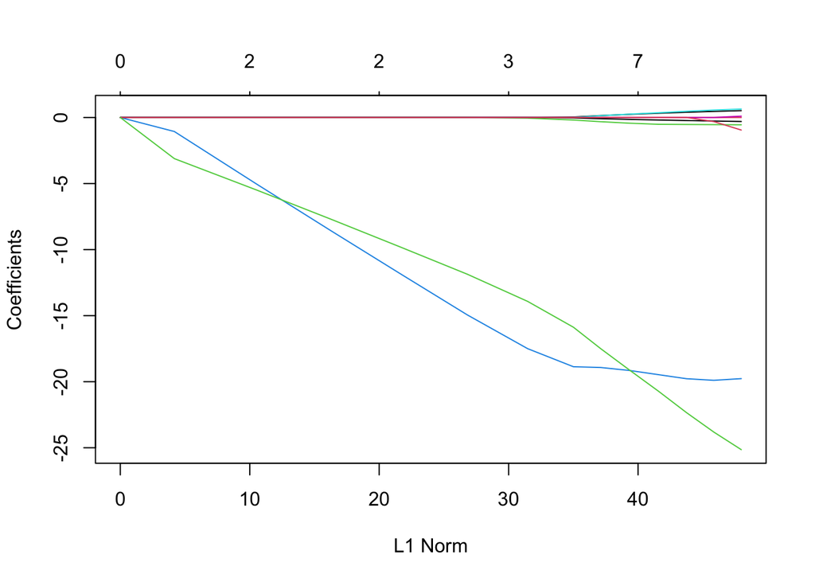

Figure 1: Lasso coefficients

I performed CV to detect the best lambda.

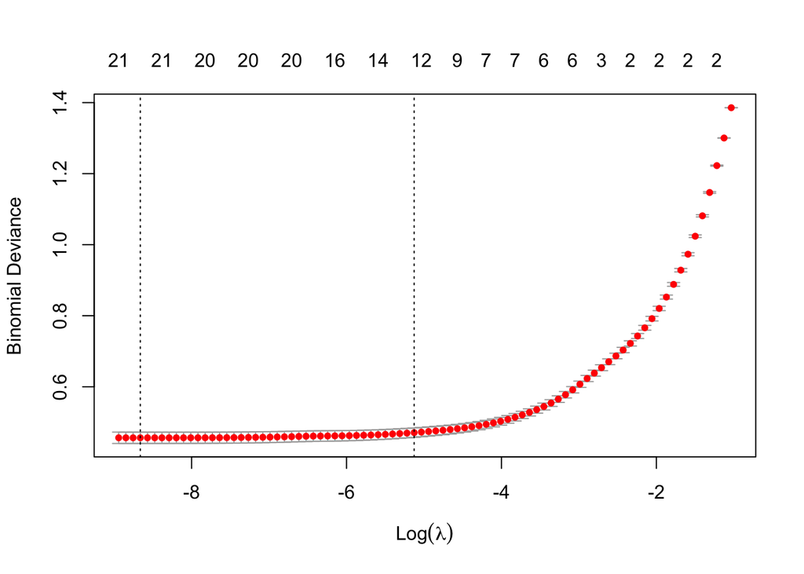

Fig. 2: lambda values in cross-validated lasso

After finding the best lambda (0.000173), I calculated the different accuracy as I did for backward and forward selection.

```
##
## accuracy: 89.59 %
```

| threshold |
| --- |
| 0.5311116 |

```
##
## accuracy with the best threshold according to the roc curve: 90.44 %
```

Also in this case, the accuracy is 89.59 %, the one with the best threshold (0.53) is 90.44 %.

I performed Lasso on the full dataset in order to find the regressors used.

```
## [1] "BioClimReg"  "Elev"        "PHIHOX"      "B11_m08"     "LAI_djf_avg"
## [6] "LAI_delta"   "B8A_m07"
```

Here there are the seven regressors that Lasso detected as useful for our analysis. Since the accuracy for the Lasso model is almost 90 %, and it does not differ a lot from the forward and backward selection and it also uses less than half of the regressors than the forward and backward selection. Hence, for the following analysis, I will use the 7-regressors model chosen by Lasso.

# 4. Data Analysis - Classification Methods

In this section I checked which method predicted the classes better among classification trees, random forest and support vector machines.  
For every method, I fitted a model using the training set found at the beginning of the paper, and predicted the data using the test set.

## 4.1. Classification tree

We fit a tree using the 7-regressor model found previously using Lasso.

```
##
## Classification tree:
## tree(formula = DLT ~ BioClimReg + Elev + PHIHOX + B11_m08 + LAI_djf_avg +
##     LAI_delta + B8A_m07, data = df_train, method = "class")
## Variables actually used in tree construction:
## [1] "B8A_m07"    "B11_m08"    "PHIHOX"     "BioClimReg"
## Number of terminal nodes:  8
## Residual mean deviance:  0.5216 = 4583 / 8786
## Misclassification error rate: 0.09961 = 876 / 8794
```

I pruned the model to find the tree with the best number of nodes.

**Table 7: pruned tree values**

| size | 8 | 7 | 5 | 2.00000 | 1 |
| --- | --- | --- | --- | --- | --- |
| dev | 1024 | 1030 | 1130 | 1206.00000 | 4529 |
| k | -Inf | 0 | 80 | 88.33333 | 3096 |

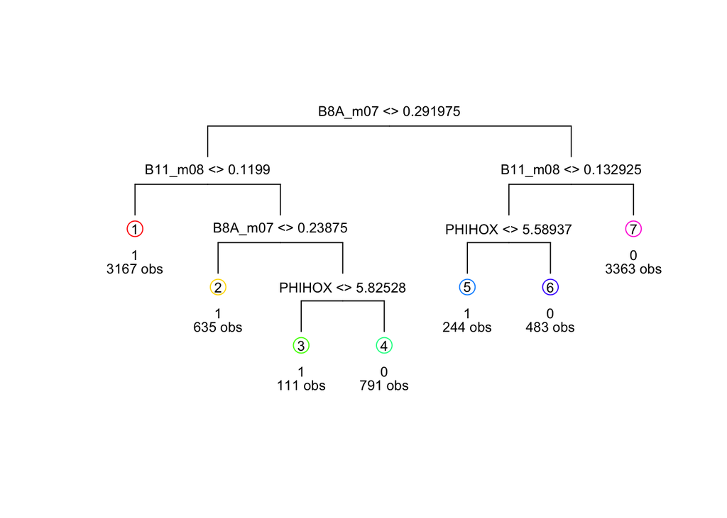

From fig. 3 we can see that the most important regressors are B8A_m07 and B11_m08. In particular, we can say that when B8A_m07 is less than 0.292 and B11_m08 is less than 0.12, DLT will be assigned to class 1 (needle-leaves). When B8A_m07 is higher than 0.292 AND B11_m08 is higher than 0.133, DLT will be assigned to class 0 (broad-leaves).

**Table 8: tree table**

|  | 0 | 1 |
| --- | --- | --- |
| 0 | 1040 | 44 |
| 1 | 75 | 243 |

```
## accuracy: 91.51 %
```

The accuracy using the classification tree is 91.51 %.

## 4.2. Bagging

I then decided to apply both bagging and random forest, remembering that bagging is just a special case of a random forest with m = p

```
## accuracy: 93.51 %
```

Bagging has an accuracy of 93.51 %. It works better than the classification tree.

I then applied Random Forest (by default, for classifcation $m =\sqrt{p}$, so in this case, since p is 7, m is rounded to 2).

## 4.3. Random Forest

**Table 9: random forest table (7-regressors model)**

|  | 0 | 1 |
| --- | --- | --- |
| 0 | 1076 | 39 |
| 1 | 39 | 248 |

```
## accuracy: 94.44 %
```

We can also see the importance of each regressor according to two measures, the mean decrease accuracy and the mean decrease Gini.

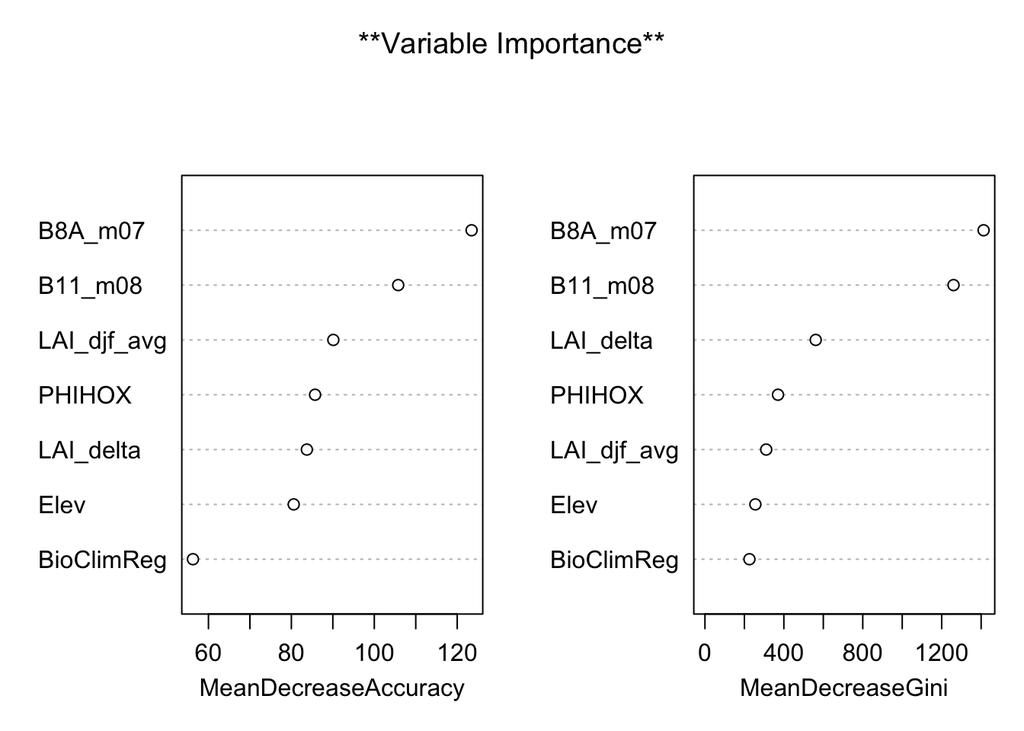

Fig. 4: Variable Importance plot for Random Forest

As expected, from the classification tree results, the two most significant variables are B8A_m07 and B11_m08.

I then tried to fit a random forest model using the 15-regressors model found during the forward selection phase to see if the accuracy increase significantly.

**Table 10: random forest table (15-regressor model)**

|  | 0 | 1 |
| --- | --- | --- |
| 0 | 1069 | 46 |
| 1 | 46 | 241 |

```
## accuracy: 93.44 %
```

The accuracy using the 15-regressors model is lower than the 7-regressors one, thus my idea to take into account just 7-regressors was right.

## 4.4 Support Vector Machine

As last analysis, I decided that I wanted to fit a support vector machine model. I fitted three different models, one using a linear kernel, one a radial kernel and one with a polynomial kernel. I did this to see which kernel performs better.

I set for every model the cost = 10, for the radial kernel model, the parameter gamma = 0.5 and for the polynomial kernel model, the parameter d = 5. Before selecting this values, I tried different combinations and I selected the best ones in terms of accuracy. I did not perform CV because for SVM it is computationally very expensive.

```
##
## accuracy linear: 89.59 %
```

```
##
## accuracy radial: 92.44 %
```

```
##
## accuracy polynomial: 92.08 %
```

The SVM model with radial kernel is the one with best accuracy, however, the accuracy on the polynomial model is similar.

# 5. Conclusion

Given the results I obtained from my analysis I can say that the two models that predicts the best the DLT is the Random Forest, with an accuracy of 94.44 %

I first decided the number of regressors to use using forward selection, backward selection and LASSO. The forward selection model recommended to use 15 regressors, with an accuracy of 90.51 % (92.57 % after CV). The backward selection recommended to use 17 regressors, with an accuracy of 90.09 % (92.71 % after CV).  
The LASSO did choose 7 regressors with an accuracy of 89.59 % (I did not do CV on LASSO).  
Since the accuracy of Lasso is similar to the accuracy of the other two methods, but Lasso did choose less regressors than the others, I decided to use the regressors found thanks to Lasso. I then fitted a Classification tree model, that gave me an accuracy of 91.51 %. Then, I tried bagging and random forests model, with accuracy respectively of 93.51 % and 94.44 %.  
Lastly, I performed SVM, but the accuracy was not high as random forest. (92.44 % using radial kernel, it was less using linear or polynomial).

The support vector machine model and the classification tree perform quite good, having accuracy respectively of 92 % and 91 % circa. I expected the classification tree to perform worse compared to the random forest because a random forest is a combination of trees, so generally it performs better. The only reasons why sometimes decision trees are preferred is because of the interpretability. Thus with similar accuracy, in this case the random forest is better because it has an accuracy of 3 % higher, but with similar accuracy I would have chosen the classification tree as best model.

# 6. Appendix

```r
knitr::opts_chunk$set(
    echo = FALSE,
    message = FALSE,
    warning = FALSE
)
# libraries and their use in this project
library(readr) # load data
library(dplyr) # data manipulation
library(knitr) # captions
library(MASS) # forward and backward selection
library(caret) # classification training (cross validation)
library(pROC) # accuracy measure
library(glmnet) # Lasso
library(tree) # classification trees
library(maptree) # tree plots
library(randomForest) # random forest
library(e1071) # SVM


df <- read_csv("trees_dataset.csv")
names(df)
# str(df) # everything is numeric
df <- na.omit(df)

df$DLT <- factor(df$DLT, labels = c(0,1))

table1 <- table(df$DLT)
names(table1) <- c("broad-leaves", "needle-leaves")
table1 <- as.data.frame(table1)
colnames(table1) <- c("class", "freq")


table1 %>%
  kable(caption ="**Table 1: DLT distribution**")

set.seed(1)
df0 <- df

df <- df %>%
  dplyr::select(-fid, -LONGITUDE, -LATITUDE)

set.seed(1)
train <- sample(nrow(df), size = nrow(df)*0.8)
df_test <- df[-train,]
df_train <- df[train,]

oversample <- df_train[sample(which(df_train$DLT == 1), length(which(df_train$DLT == 0)), replace = T), ]

df_train <- rbind(df_train[(df_train$DLT == 0),], oversample)

table1 <- table(df_train$DLT)
names(table1) <- c("broad-leaves", "needle-leaves")
table1 <- as.data.frame(table1)
colnames(table1) <- c("class", "freq")


table1 %>%
  kable(caption ="**Table 2: DLT distribution on the training set (after oversampling)**")

# FORWARD SELECTION ----

set.seed(1)
logistic_model <- glm(DLT ~ ., data = df_train, family = "binomial")
null_model <- glm(DLT ~ 1, data = df_train, family = "binomial")


regfit.fwd <- stepAIC(null_model,direction="forward",scope=list(upper=logistic_model,lower=null_model), trace = F)
names(coef(regfit.fwd))[-1] #15 regressors
set.seed(1)
pred <- predict(regfit.fwd, df_test, type = "response")
pred_class <- ifelse(pred <= 0.5, "broad-leaves", "needle-leaves")
pred_table <- table(df_test$DLT, pred_class)

pred_table %>%
  kable(caption ="**Table 3: prediction table forward model**")

accuracy <- (pred_table[1,1] + pred_table[2,2]) / nrow(df_test)
cat("accuracy:",round(accuracy*100, 2), "%")

# increase accuracy

set.seed(1)
coords(roc(df_test$DLT, pred), "best", ret = c("threshold"))
# using this instead of 0.5 will not change a lot the results

pred_class1 <- ifelse(pred <= 0.5257392, "broad-leaves", "needle-leaves")
pred_table1 <- table(df_test$DLT, pred_class1)

pred_table1 %>%
  kable(caption ="**Table 4: prediction table forward model (threshold 0.53)**")

accuracy1 <- (pred_table1[1,1] + pred_table1[2,2]) / nrow(df_test)
cat("accuracy using roc curve best threshold:",round(accuracy1*100, 2), "%")

set.seed(1)
folds <- createFolds(1:nrow(df), k = 5)
accuracy <- rep(0,5)
for (i in 1:length(folds)) {
  test <- df[folds[[i]],]
  train <- df[-folds[[i]],]
  log.fit.fwd <- glm(DLT ~ B8A_m07+B11_m08+PHIHOX+LAI_djf_avg+BioClimReg+Lat+LAI_delta+Elev+dCoastLog+NDYI_m10+B11_m07+B11_m05+TannNorm+EVI_m03+CRFann,
                     data = train, family = "binomial")

  pred <- predict(log.fit.fwd, test, type = "response")
  pred_class <- ifelse(pred <= 0.5, "broad-leaves", "needle-leaves")
  pred_table <- table(test$DLT, pred_class)
  accuracy[i] <- (pred_table[1,1] + pred_table[2,2]) / nrow(test)
}
cat("accuracy using CV on the 15-regressor model:",round(mean(accuracy)*100, 2), "%")
set.seed(1)
# BACKWARD SELECTION ----
regfit.bwd <- stepAIC(logistic_model,direction="backward",scope=list(upper=logistic_model,lower=null_model), trace = F)
names(coef(regfit.bwd))[-1] #17 variables
set.seed(1)
pred <- predict(regfit.bwd, df_test, type = "response")
pred_class <- ifelse(pred <= 0.5, "broad-leaves", "needle-leaves")
pred_table <- table(df_test$DLT, pred_class)

pred_table %>%
  kable(caption ="**Table 5: prediction table backward model**")

accuracy <- (pred_table[1,1] + pred_table[2,2]) / nrow(df_test)
cat("accuracy:",round(accuracy*100, 2), "%")

set.seed(1)
coords(roc(df_test$DLT, pred), "best", ret = c("threshold"))

set.seed(1)
pred_class1 <- ifelse(pred <= 0.5390742, "broad-leaves", "needle-leaves")
pred_table1 <- table(df_test$DLT, pred_class1)

pred_table1 %>%
  kable(caption ="**Table 6: prediction table backward model (threshold 0.54)**")

accuracy <- (pred_table1[1,1] + pred_table1[2,2]) / nrow(df_test)
cat("
accuracy using roc curve best threshold:",round(accuracy*100, 2), "%")

# CV after having selected the model in backward selection ----

set.seed(1)
folds <- createFolds(1:nrow(df), k = 5)
accuracy <- rep(0,5)
for (i in 1:length(folds)) {
  test <- df[folds[[i]],]
  train <- df[-folds[[i]],]
  log.fit.bwd <- glm(DLT ~ dCoastLog+Lat+CRFann+BioClimReg+Elev+PHIHOX+LAI_std+B11_m08+TannNorm+LAI_djf_avg+B11_m07+B12_m03+NDYI_m10+LAI_delta+B11_m03+B11_m05+B8A_m07,
                     data = train, family = "binomial")

  pred <- predict(log.fit.bwd, test, type = "response")
  pred_class <- ifelse(pred <= 0.5, "broad-leaves", "needle-leaves")
  pred_table <- table(test$DLT, pred_class)
  accuracy[i] <- (pred_table[1,1] + pred_table[2,2]) / nrow(test)
}
cat("
accuracy using CV on the 17-regressor model:",round(mean(accuracy)*100, 2), "%")
set.seed(1)
grid <- 10^seq(10, -2, length = 100)

x <- model.matrix(DLT ~ ., df)[,-1] #-1 (remove the intercept)
y <- df$DLT

x.train <- model.matrix(DLT ~ ., df_train)[,-1] #-1 (remove the intercept)
y.train <- df_train$DLT

x.test <- model.matrix(DLT ~ ., df_test)[,-1] #-1 (remove the intercept)
y.test <- df_test$DLT


# In this way, we have the same split as before

lasso.mod <- glmnet(x.train, y.train, alpha = 1,
                    lambda = grid, family = "binomial")
par(mfrow = c(1,1))
plot(lasso.mod)
set.seed(1)
cv.out <- cv.glmnet(x.train, y.train, alpha = 1, family = "binomial")
plot(cv.out)
bestlam <- cv.out$lambda.min
lasso.pred <- predict(lasso.mod, s = bestlam,
                      newx = x.test, type = "response")
pred_class <- ifelse(lasso.pred <= 0.5, "broad-leaves", "needle-leaves")
pred_table <- table(y.test, pred_class)
accuracy <- (pred_table[1,1] + pred_table[2,2]) / length(y.test)
cat("
accuracy:",round(accuracy*100, 2), "%")

# increase accuracy
coords(roc(y.test, lasso.pred), "best", ret = c("threshold"))
pred_class <- ifelse(lasso.pred <= 0.5311116, "broad-leaves", "needle-leaves")
pred_table <- table(y.test, pred_class)
accuracy <- (pred_table[1,1] + pred_table[2,2]) / length(y.test)
cat("
accuracy with the best threshold according to the roc curve:",round(accuracy*100, 2), "%")
# perform Lasso on the full data set
set.seed(1)
out <- glmnet(x, y, alpha = 1, lambda = grid, family = "binomial")
lasso.coef <- predict(out, type = "coefficients",
                      s = bestlam)[1:22, ]
# lasso.coef
names(lasso.coef[lasso.coef != 0])[-1] # 7 regressors chosen
# CLASSIFICATION TREES ----

set.seed(1)
tree.fit <- tree(DLT ~ BioClimReg+Elev+PHIHOX+B11_m08+LAI_djf_avg+LAI_delta+B8A_m07,
                           method="class", data=df_train)
summary(tree.fit)
# CV on tree
set.seed(1)
cv.df <- cv.tree(tree.fit, FUN = prune.misclass)

size <- cv.df$size # number of terminal nodes
dev <- cv.df$dev #number of CV errors
k <-cv.df$k # value of the cost-complexity parameter
data <- as.data.frame(t(size))
colnames(data) <- c(rep(NULL, 4))
data <- rbind(data, dev, k)
rownames(data) <- c("size", "dev", "k")

data %>%
  kable(caption ="**Table 7: pruned tree values**")
library(maptree)
# prune.misclass() function in order to prune the tree to obtain the tree-node tree.
set.seed(1)
prune.df <- prune.misclass(tree.fit, best = 7)
draw.tree(prune.df, cex = 0.8)
# calculate accuracy
tree.pred <- predict(prune.df, df_test, type = "class")
tree.table <- table(tree.pred, df_test$DLT)

tree.table %>%
  kable(caption = "**Table 8: tree table**")

accuracy <- (tree.table[1,1] + tree.table[2,2]) / nrow(df_test)
cat("accuracy:",round(accuracy*100, 2), "%")
# Bagging and Random Forests ----

# Bagging:
set.seed(1)
bag.df <- randomForest(DLT ~ BioClimReg+Elev+PHIHOX+B11_m08+LAI_djf_avg+LAI_delta+B8A_m07, data= df_train, mtry = 7, importance = TRUE, family = "binomial")
# How well bagging perform on the set?
yhat.bag <- predict(bag.df, newdata = df_test, type = "response")
bag.table <- table(yhat.bag, df_test$DLT)
accuracy <- (bag.table[1,1] + bag.table[2,2]) / nrow(df_test)
cat("accuracy:",round(accuracy*100, 2), "%")
# Random Forest ----

set.seed(1)
rf.df <- randomForest(DLT ~ BioClimReg+Elev+PHIHOX+B11_m08+LAI_djf_avg+LAI_delta+B8A_m07, data = df_train, importance = TRUE, family = "binomial")
yhat.rf <- predict(rf.df, newdata = df_test, type = "response")
rf.table <- table(yhat.rf, df_test$DLT)
rf.table %>%
  kable(caption = "**Table 9: random forest table (7-regressors model)**")

accuracy <- (rf.table[1,1] + rf.table[2,2]) / nrow(df_test)
cat("accuracy:",round(accuracy*100, 2), "%")
varImpPlot(rf.df, main = "**Variable Importance**", offset = 0.1)
set.seed(1)
rf.df <- randomForest(DLT ~ B8A_m07+B11_m08+PHIHOX+LAI_djf_avg+BioClimReg+Lat+LAI_delta+Elev+dCoastLog+NDYI_m10+B11_m07+B11_m05+TannNorm+EVI_m03+CRFann, data = df_train, importance = TRUE, family = "binomial")
yhat.rf <- predict(rf.df, newdata = df_test, type = "response")
rf.table <- table(yhat.rf, df_test$DLT)
rf.table %>%
  kable(caption = "**Table 10: random forest table (15-regressor model)**")

accuracy <- (rf.table[1,1] + rf.table[2,2]) / nrow(df_test)
cat("accuracy:",round(accuracy*100, 2), "%")
set.seed(1)

df_svm <- df %>%
  dplyr::select(DLT, BioClimReg, Elev, PHIHOX, B11_m08, LAI_djf_avg, LAI_delta, B8A_m07)

df_svm_train <- df_train %>%
  dplyr::select(DLT, BioClimReg, Elev, PHIHOX, B11_m08, LAI_djf_avg, LAI_delta, B8A_m07)

df_svm_test <- df_test %>%
  dplyr::select(DLT, BioClimReg, Elev, PHIHOX, B11_m08, LAI_djf_avg, LAI_delta, B8A_m07)

set.seed(1)
svm.fit <- svm(DLT ~ ., data = df_svm_train, kernel = "linear", cost = 10)
set.seed(1)
svm.fit2 <- svm(DLT ~ ., data = df_svm_train, kernel = "radial", cost = 10, gamma = 0.5)
set.seed(1)
svm.fit3 <- svm(DLT ~ ., data = df_svm_train, kernel = "polynomial", cost = 10, d = 5)

# check the performance on test set

pred.te <- predict(svm.fit, newdata = df_svm_test)
svm.table <- table(pred.te, df_svm_test$DLT)
accuracy <- (svm.table[1,1] + svm.table[2,2]) / nrow(df_svm_test)
cat("
accuracy linear:", round(mean(accuracy)*100,2), "%")

pred.te <- predict(svm.fit2, newdata = df_svm_test)
svm.table <- table(pred.te, df_svm_test$DLT)
accuracy <- (svm.table[1,1] + svm.table[2,2]) / nrow(df_svm_test)
cat("
accuracy radial:", round(mean(accuracy)*100,2), "%")

pred.te <- predict(svm.fit3, newdata = df_svm_test)
svm.table <- table(pred.te, df_svm_test$DLT)
accuracy <- (svm.table[1,1] + svm.table[2,2]) / nrow(df_svm_test)
cat("
accuracy polynomial:", round(mean(accuracy)*100,2), "%")
```